```python
%matplotlib inline
import pandas as pd
import seaborn as sns
import plotly.express as px

import matplotlib.pyplot as plt
```

```python
import plotly.io as pio
pio.renderers.default = "plotly_mimetype+notebook"
```

# Matplotlib

For this excercise, we have written the following code to load the stock dataset built into plotly express.

```python
stocks = px.data.stocks()
stocks.head()
```

|  | date | GOOG | AAPL | AMZN | FB | NFLX | MSFT |
| --- | --- | --- | --- | --- | --- | --- | --- |
| 0 | 2018-01-01 | 1.000000 | 1.000000 | 1.000000 | 1.000000 | 1.000000 | 1.000000 |
| 1 | 2018-01-08 | 1.018172 | 1.011943 | 1.061881 | 0.959968 | 1.053526 | 1.015988 |
| 2 | 2018-01-15 | 1.032008 | 1.019771 | 1.053240 | 0.970243 | 1.049860 | 1.020524 |
| 3 | 2018-01-22 | 1.066783 | 0.980057 | 1.140676 | 1.016858 | 1.307681 | 1.066561 |
| 4 | 2018-01-29 | 1.008773 | 0.917143 | 1.163374 | 1.018357 | 1.273537 | 1.040708 |

## Question 1:

Select a stock and create a suitable plot for it. Make sure the plot is readable with relevant information, such as date, values.

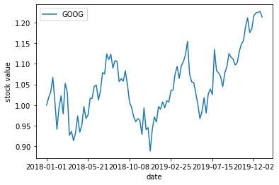

```python
#Creating a line chart showing the stock value of Google over time

stocks.plot(x='date', y='GOOG')
plt.xlabel('date')
plt.ylabel('stock value')
```

## Question 2:

You've already plot data from one stock. It is possible to plot multiples of them to support comparison.  
To highlight different lines, customise line styles, markers, colors and include a legend to the plot.

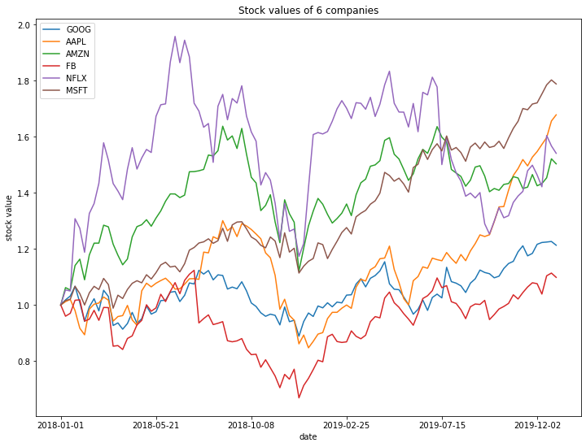

```python
#Creating a line chart showing the stock value of six different companies over time

stocks.plot(x='date', figsize=(12, 9))

plt.xlabel('date')
plt.ylabel('stock value')

plt.title(label="Stock values of 6 companies")
```

# Seaborn

First, load the [tips](https://github.com/mwaskom/seaborn-data/blob/master/tips.csv) dataset

```python
tips = sns.load_dataset('tips')
tips.head()
```

|  | total_bill | tip | sex | smoker | day | time | size |
| --- | --- | --- | --- | --- | --- | --- | --- |
| 0 | 16.99 | 1.01 | Female | No | Sun | Dinner | 2 |
| 1 | 10.34 | 1.66 | Male | No | Sun | Dinner | 3 |
| 2 | 21.01 | 3.50 | Male | No | Sun | Dinner | 3 |
| 3 | 23.68 | 3.31 | Male | No | Sun | Dinner | 2 |
| 4 | 24.59 | 3.61 | Female | No | Sun | Dinner | 4 |

## Question 3:

Let's explore this dataset. Pose a question and create a plot that support drawing answers for your question.

Some possible questions:

- Are there differences between male and female when it comes to giving tips?
- What attribute correlate the most with tip?

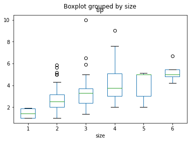

```python
#Creating a boxplot to answer the question below.

# Question: Does the tip depend on the group size?
# Answer: Yes the bigger the group, the higher the tip

tips.boxplot(by ='size', column =['tip'], grid = False)
```

# Plotly Express

## Question 4:

Redo the above exercises (challenges 2 & 3) with plotly express. Create diagrams which you can interact with.

The stocks dataset

Hints:

Turn stock dataframe into a structure that can be picked up easily with plotly express

```python
stocks.head()
```

|  | date | GOOG | AAPL | AMZN | FB | NFLX | MSFT |
| --- | --- | --- | --- | --- | --- | --- | --- |
| 0 | 2018-01-01 | 1.000000 | 1.000000 | 1.000000 | 1.000000 | 1.000000 | 1.000000 |
| 1 | 2018-01-08 | 1.018172 | 1.011943 | 1.061881 | 0.959968 | 1.053526 | 1.015988 |
| 2 | 2018-01-15 | 1.032008 | 1.019771 | 1.053240 | 0.970243 | 1.049860 | 1.020524 |
| 3 | 2018-01-22 | 1.066783 | 0.980057 | 1.140676 | 1.016858 | 1.307681 | 1.066561 |
| 4 | 2018-01-29 | 1.008773 | 0.917143 | 1.163374 | 1.018357 | 1.273537 | 1.040708 |

```python
#Creating a line chart using plotly express

fig = px.line(stocks, x='date', y=stocks.keys())
#fig = px.line(stocks, x='date', y='GOOG')
fig.show()
```

[interactive chart not shown]

### The tips dataset

```python
#Creating a boxplot using plotly express

# Question: Does the total tip depend on the group size?
# Answer: Yes the bigger the group, the higher the tip

fig = px.box(datatips, x="size", y="tip")
fig.show()
```

[interactive chart not shown]

## Question 5:

*Hints:*

- Extract the 2007 year data from the dataframe. You have to process the data accordingly
- use [plotly bar](https://plotly.com/python-api-reference/generated/plotly.express.bar)
- Add different colors for different continents
- Sort the order of the continent for the visualisation. Use [axis layout setting](https://plotly.com/python/reference/layout/xaxis/)
- Add text to each bar that represents the population

```python
#load data
df = px.data.gapminder()
df.head()
```

|  | country | continent | year | lifeExp | pop | gdpPercap | iso_alpha | iso_num |
| --- | --- | --- | --- | --- | --- | --- | --- | --- |
| 0 | Afghanistan | Asia | 1952 | 28.801 | 8425333 | 779.445314 | AFG | 4 |
| 1 | Afghanistan | Asia | 1957 | 30.332 | 9240934 | 820.853030 | AFG | 4 |
| 2 | Afghanistan | Asia | 1962 | 31.997 | 10267083 | 853.100710 | AFG | 4 |
| 3 | Afghanistan | Asia | 1967 | 34.020 | 11537966 | 836.197138 | AFG | 4 |
| 4 | Afghanistan | Asia | 1972 | 36.088 | 13079460 | 739.981106 | AFG | 4 |

```python
#Creating a bar diagram showing the population per continent

df_2007 = df.query('year==2007')
df_2007_new = df_2007.groupby('continent').sum()

fig = px.bar(df_2007_new, x="pop", orientation='h', color = df_2007_new.index)

fig.show()
```

[interactive chart not shown]